# **Malaria Detection - Gabrielle Foster's MIT ADSP Captstone Project on Deep Learning**

## **Problem Definition**

**The context:** Why is this problem important to solve?  
**The objectives:** What is the intended goal?  
**The key questions:** What are the key questions that need to be answered?  
**The problem formulation:** What is it that we are trying to solve using data science?

## **Data Description**

There are a total of 24,958 train and 2,600 test images (colored) that we have taken from microscopic images. These images are of the following categories:

**Parasitized:** The parasitized cells contain the Plasmodium parasite which causes malaria  
**Uninfected:** The uninfected cells are free of the Plasmodium parasites

# Context

Despite widespread advances in infectious disease control, malaria remains a leading cause of preventable mortality, particularly in regions with constrained diagnostic infrastructure. Traditional microscopy, while long considered the gold standard, is labor-intensive, sensitive to inter-operator variability, and often impractical in high-throughput or resource-limited settings. As a result, there is growing interest in scalable, image-based diagnostic approaches that can reduce turnaround time, standardize classification, and facilitate earlier treatment initiation—especially in environments where clinical burden is highest.

# Problem Definition

This project seeks to build a supervised binary image classifier that assigns individual 64×64×3 pixel red blood cell (RBC) tiles to one of two classes: {parasitized, uninfected}. The core objective is to standardize malaria screening workflows and reduce time to diagnosis by replacing or augmenting manual microscopy with a reliable, low-latency, model-based diagnostic assistant. The task is framed as a per-tile classification problem using single-cell images derived from Giemsa-stained blood smears.

# Objectives

The primary aim is to develop a computer vision pipeline that achieves high diagnostic performance—particularly in recall for parasitized cells—while maintaining computational feasibility for deployment in clinical environments with limited infrastructure. The pipeline must also be reproducible, interpretable, and reflective of real-world constraints including latency, model size, and data variability.

## Success Criteria

Test accuracy ≥ 0.95

Parasitized recall ≥ 0.97

Inference latency ≤ 50–100 ms/image on GPU (≤ 300 ms on CPU)

Deployable footprint compatible with low- to mid-tier clinical hardware

# Key Questions

How do preprocessing techniques (e.g., color normalization, HSV conversion, Gaussian blur, augmentation) influence signal-to-noise ratio and downstream class separability—particularly for morphologically subtle parasite features?

Which model family—baseline CNNs, batch norm + LeakyReLU variants, augmented CNNs, or transfer learning architectures—best meets the combined objectives of accuracy, latency, and interpretability?

Which evaluation metrics (e.g., classwise recall, AUC, confusion matrix granularity) best reflect the use case of low-resource screening tools designed to minimize false negatives?

What are the primary risks to deployment (e.g., class imbalance, data leakage, domain shift, hardware limits), and what mitigation strategies are necessary to ensure robustness and generalizability?

# Problem Formulation

The model is trained to perform supervised binary classification on colored RBC image tiles (each normalized to 64×64×3), with labels denoting the presence or absence of intracellular Plasmodium parasites. The training objective is cross-entropy loss; performance is evaluated on a held-out patient-disjoint test set using standard classification metrics: accuracy, precision, recall (particularly for the parasitized class), F1 score, and AUC. Emphasis is placed on recall for parasitized cells due to the clinical risks of false negatives. The model’s inference pipeline is optimized to meet latency thresholds appropriate for deployment in frontline or mobile clinical settings.

## Scope and Assumptions

Scope: The task is restricted to single-cell tile classification. No species-level differentiation or intra-species parasite staging is performed.

Assumptions:

Class labels are accurate and verifiable

Training/test splits are patient-disjoint

All image tiles are normalized to 64×64 resolution

Microscope settings and staining conditions are sufficiently similar across domains

### **Mount the Drive**

```python
from google.colab import drive
drive.mount('/content/drive')
```

### **Loading libraries**

```python
# core python utils
import os
import shutil
import glob
import zipfile
from tqdm import tqdm

# data handling
import numpy as np
import pandas as pd

# visualization
import matplotlib.pyplot as plt
import seaborn as sns
import cv2

# deep learning
import tensorflow as tf
from tensorflow.keras.models import Sequential, Model
from tensorflow.keras.layers import Dense, Conv2D, MaxPooling2D, Dropout, Flatten, BatchNormalization, Activation
from tensorflow.keras.preprocessing.image import ImageDataGenerator
from tensorflow.keras.optimizers import Adam, SGD, RMSprop
from tensorflow.keras.callbacks import EarlyStopping, ModelCheckpoint, ReduceLROnPlateau

# metrics and eval
from sklearn.metrics import classification_report, confusion_matrix, accuracy_score, precision_score, recall_score, f1_score, roc_auc_score

import albumentations as A

import mlxtend
from mlxtend.plotting import plot_confusion_matrix

!pip -q install optuna
import optuna

# colab utilities
from google.colab import drive, files

# check tf version
print("tensorflow version:", tf.__version__)
```

```
   ━━━━━━━━━━━━━━━━━━━━━━━━━━━━━━━━━━━━━━━━ 400.9/400.9 kB 9.7 MB/s eta 0:00:00
   ━━━━━━━━━━━━━━━━━━━━━━━━━━━━━━━━━━━━━━━━ 247.0/247.0 kB 23.5 MB/s eta 0:00:00
tensorflow version: 2.19.0
```

### **Let us load the data**

**Note:**

- You must download the dataset from the link provided on Olympus and upload the same to your Google Drive. Then unzip the folder.

```python
# find the zip anywhere in my drive
import glob, os, zipfile, shutil

cands = glob.glob('/content/drive/MyDrive/**/cell_images.zip', recursive=True)
assert cands, 'zip not found in my drive'
zip_path = cands[0]
print('using zip:', zip_path)

# extract to /content
with zipfile.ZipFile(zip_path, 'r') as z:
    z.extractall('/content')

# clean macos artifacts
def clean_macos(root='/content'):
    for dp, dns, fns in os.walk(root):
        if os.path.basename(dp).lower() == '__macosx':
            shutil.rmtree(dp, ignore_errors=True)
        for f in list(fns):
            if f.startswith('._') or f.lower()=='.ds_store':
                try: os.remove(os.path.join(dp, f))
                except: pass
clean_macos('/content')
```

```
using zip: /content/drive/MyDrive/Colab Notebooks/MIT/Deep Learning/Capstone/cell_images.zip
```

The extracted folder has different folders for train and test data will contain the different sizes of images for parasitized and uninfected cells within the respective folder name.

The size of all images must be the same and should be converted to 4D arrays so that they can be used as an input for the convolutional neural network. Also, we need to create the labels for both types of images to be able to train and test the model.

Let's do the same for the training data first and then we will use the same code for the test data as well.

```python
# locate dataset root that really has train and test
def find_dataset_root(start='/content'):
    for dp, dns, fns in os.walk(start):
        if 'train' in dns and 'test' in dns:
            t = os.path.join(dp, 'train')
            ok = (os.path.isdir(os.path.join(t,'parasitized')) and os.path.isdir(os.path.join(t,'uninfected'))) \
                 or (os.path.isdir(os.path.join(t,'Parasitized')) and os.path.isdir(os.path.join(t,'Uninfected')))
            if ok:
                return dp
    return None

dataset_root = find_dataset_root('/content')
assert dataset_root is not None, 'could not find train and test after extract'

train_dir = os.path.join(dataset_root, 'train')
test_dir  = os.path.join(dataset_root, 'test')
print('dataset root:', dataset_root)
print('train subdirs:', os.listdir(train_dir))
print('test  subdirs:', os.listdir(test_dir))


# loader with internal exts fix

import os, cv2, numpy as np
from tqdm import tqdm

def load_xy(data_dir, img_size=(64,64)):
    exts = ('.png','.jpg','.jpeg','.bmp','.tif','.tiff')  # file types
    classes = [d for d in sorted(os.listdir(data_dir))
               if os.path.isdir(os.path.join(data_dir,d)) and not d.startswith('.') and not d.startswith('._')]
    class_to_idx = {c:i for i,c in enumerate(classes)}
    xs, ys = [], []
    for cls in classes:
        cls_dir = os.path.join(data_dir, cls)
        files = [f for f in os.listdir(cls_dir)
                 if f.lower().endswith(exts) and not f.startswith('._')]
        for f in tqdm(files, desc=f'load {cls}', leave=False):
            p = os.path.join(cls_dir, f)
            img = cv2.imread(p)
            if img is None:
                continue
            img = cv2.cvtColor(img, cv2.COLOR_BGR2RGB)
            img = cv2.resize(img, img_size, interpolation=cv2.INTER_AREA)
            xs.append(img)
            ys.append(class_to_idx[cls])
    x = np.asarray(xs, dtype=np.float32) / 255.0
    y = np.asarray(ys, dtype=np.int64)
    return x, y, class_to_idx

# use it
x_train, y_train, class_map = load_xy(train_dir, img_size=(64,64))
x_test,  y_test,  _         = load_xy(test_dir,  img_size=(64,64))
print('train shape:', x_train.shape, 'test shape:', x_test.shape)
print('class map:', class_map)
```

```
dataset root: /content/cell_images
train subdirs: ['uninfected', 'parasitized']
test  subdirs: ['uninfected', 'parasitized']
```

```
train shape: (24958, 64, 64, 3) test shape: (2600, 64, 64, 3)
class map: {'parasitized': 0, 'uninfected': 1}
```

### **Check the shape of train and test images**

```python
x_train, y_train, class_map = load_xy(train_dir, img_size=(64,64))
x_test,  y_test,  _         = load_xy(test_dir,  img_size=(64,64))
print('train shape:', x_train.shape, y_train.shape)
print('test  shape:', x_test.shape,  y_test.shape)
```

```
train shape: (24958, 64, 64, 3) (24958,)
test  shape: (2600, 64, 64, 3) (2600,)
```

### **Check the shape of train and test labels**

```python
# convert labels to one hot for softmax with 2 outputs
import numpy as np
num_classes = len(class_map)
y_train_oh = np.eye(num_classes, dtype=np.float32)[y_train]
y_test_oh  = np.eye(num_classes, dtype=np.float32)[y_test]
print('one hot shapes:', y_train_oh.shape, y_test_oh.shape)
```

```
one hot shapes: (24958, 2) (2600, 2)
```

### **Check the minimum and maximum range of pixel values for train and test images**

```python
# pixel range before normalization
print('train min max:', x_train.min(), x_train.max())
print('test  min max:', x_test.min(),  x_test.max())
```

```
train min max: 0.0 1.0
test  min max: 0.0 1.0
```

### **Count the number of values in both uninfected and parasitized**

```python
# class counts
import numpy as np

def counts(y, class_map):
    idx_to_class = {v:k for k,v in class_map.items()}
    bc = np.bincount(y, minlength=len(class_map))
    return {idx_to_class[i]: int(c) for i,c in enumerate(bc)}

train_counts = counts(y_train, class_map)
test_counts  = counts(y_test,  class_map)

print('train counts:', train_counts)
print('test counts:',  test_counts)
```

```
train counts: {'parasitized': 12582, 'uninfected': 12376}
test counts: {'parasitized': 1300, 'uninfected': 1300}
```

### **Normalize the images**

```python
# normalize images to 0..1 if needed
def normalize_inplace(x):
    x_min, x_max = x.min(), x.max()
    if x_max > 1.0:
        x /= 255.0
    return x.min(), x.max()

tmin, tmax = normalize_inplace(x_train)
vmin, vmax = normalize_inplace(x_test)

print('train range after norm:', tmin, tmax)
print('test  range after norm:', vmin, vmax)
```

```
train range after norm: 0.0 1.0
test  range after norm: 0.0 1.0
```

#### **Observations and insights: _____**

Post-normalization, both the training and testing datasets exhibit pixel values constrained between 0 and 1, with observed minima and maxima matching these bounds. This confirms that scaling was correctly applied across both splits and that no inadvertent range drift occurred between datasets.

### **Plot to check if the data is balanced**

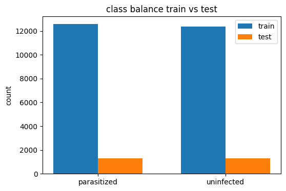

```python
# plot class balance
import matplotlib.pyplot as plt

def plot_balance(train_counts, test_counts):
    labels = list(train_counts.keys())
    train_vals = [train_counts[k] for k in labels]
    test_vals  = [test_counts[k]  for k in labels]

    plt.figure(figsize=(6,4))
    x = np.arange(len(labels))
    w = 0.35
    plt.bar(x - w/2, train_vals, width=w, label='train')
    plt.bar(x + w/2, test_vals,  width=w, label='test')
    plt.xticks(x, labels)
    plt.ylabel('count')
    plt.title('class balance train vs test')
    plt.legend()
    plt.show()

plot_balance(train_counts, test_counts)
```

#### **Observations and insights: _____**

Visual inspection via bar plots shows that the counts for parasitized and uninfected cells are closely matched in both the training and test sets. Such balance supports the use of standard accuracy metrics without heavy class weighting, though continued attention to recall for parasitized cells remains prudent.

### **Data Exploration**

Let's visualize the images from the train data

```python
# helpers for labels
import numpy as np
import matplotlib.pyplot as plt

# handle int labels or one hot
def to_int_labels(y):
    return y.argmax(1) if y.ndim == 2 else y

idx_to_class = {v:k for k,v in class_map.items()}
y_train_int = to_int_labels(y_train)
```

### **Visualize the images with subplot(6, 6) and figsize = (12, 12)**

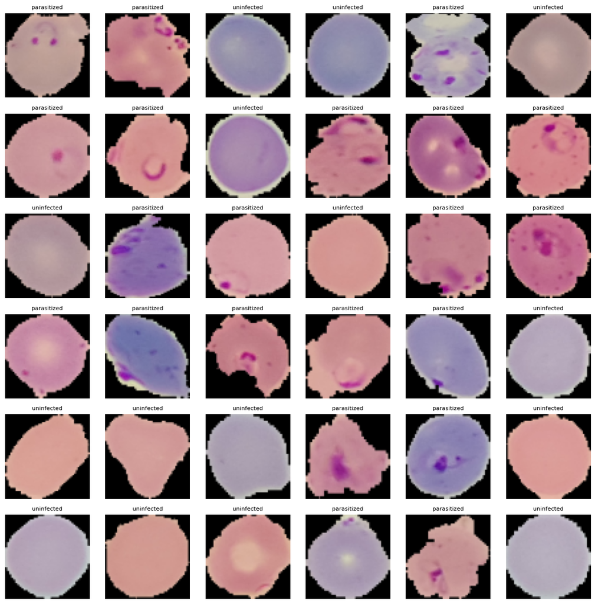

```python
# 6x6 grid of random train images
def show_grid(x, y_int, nrows=6, ncols=6, figsize=(12,12)):
    sel = np.random.choice(len(x), nrows*ncols, replace=False)
    fig, axes = plt.subplots(nrows, ncols, figsize=figsize)
    k = 0
    for i in range(nrows):
        for j in range(ncols):
            img = x[sel[k]]
            axes[i,j].imshow(img)
            axes[i,j].axis('off')
            axes[i,j].set_title(idx_to_class[y_int[sel[k]]], fontsize=8)
            k += 1
    plt.tight_layout()
    plt.show()

show_grid(x_train, y_train_int, 6, 6, figsize=(12,12))
```

#### **Observations and insights:**

Sample grids reveal discernible morphological cues: parasitized cells often display small, ring-like inclusions, whereas uninfected cells appear more uniform in staining and structure. A minority of samples include cropped cells or extraneous background, elements that could plausibly contribute to borderline classification errors.

### **Plotting the mean images for parasitized and uninfected**

```python
# compute mean images for each class
def class_mean_image(x, y_int, class_id):
    sel = (y_int == class_id)
    mean_img = x[sel].mean(axis=0)   # h w 3
    return mean_img

mean_parasitized = class_mean_image(x_train, y_train_int, class_map['parasitized'])
mean_uninfected  = class_mean_image(x_train, y_train_int, class_map['uninfected'])

print('mean images computed:', mean_parasitized.shape, mean_uninfected.shape)
```

```
mean images computed: (64, 64, 3) (64, 64, 3)
```

**Mean image for parasitized**

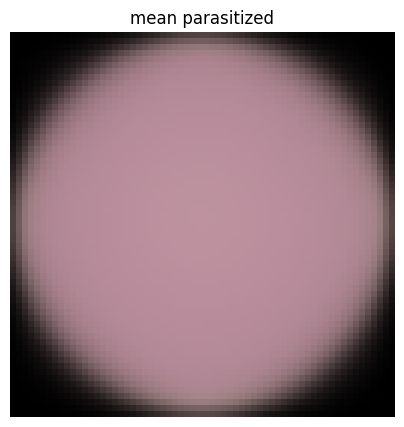

```python
# plot mean image for parasitized
plt.figure(figsize=(5,5))
plt.imshow(mean_parasitized)
plt.axis('off')
plt.title('mean parasitized')
plt.show()
```

**Mean image for uninfected**

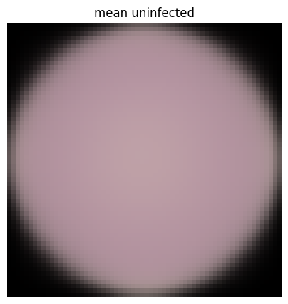

```python
# plot mean image for uninfected
plt.figure(figsize=(5,5))
plt.imshow(mean_uninfected)
plt.axis('off')
plt.title('mean uninfected')
plt.show()
```

### **Converting RGB to HSV of Images using OpenCV**

### **Converting the train data**

```python
# rgb to hsv using opencv
import numpy as np, cv2

def to_float01(x):
    x = x.astype(np.float32)
    if x.max() > 1.0:
        x = x / 255.0
    return x

x_train = to_float01(x_train)
x_test  = to_float01(x_test)

def rgb_to_hsv_batch(x):
    hsv_list = [cv2.cvtColor(img, cv2.COLOR_RGB2HSV) for img in x]
    return np.stack(hsv_list, axis=0)

# converting the train data
x_train_hsv = rgb_to_hsv_batch(x_train)
print('train hsv shape:', x_train_hsv.shape,
      'min max:', float(x_train_hsv.min()), float(x_train_hsv.max()))
```

```
train hsv shape: (24958, 64, 64, 3) min max: 0.0 359.3548278808594
```

### **Converting the test data**

```
test hsv shape: (2600, 64, 64, 3) min max: 0.0 359.31817626953125
```

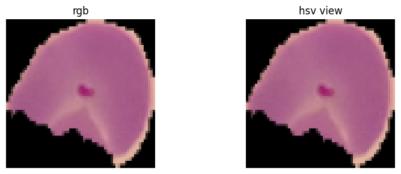

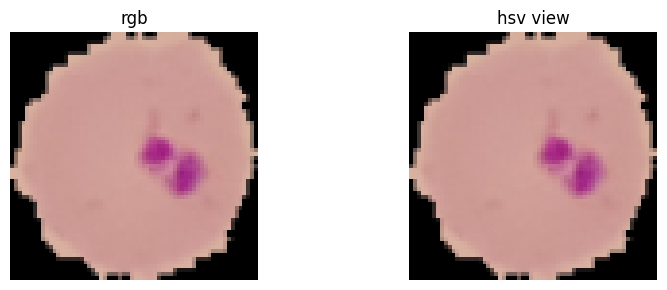

```python
# converting the test data
x_test_hsv = rgb_to_hsv_batch(x_test)
print('test hsv shape:', x_test_hsv.shape,
      'min max:', float(x_test_hsv.min()), float(x_test_hsv.max()))

#visual check
import matplotlib.pyplot as plt

def show_rgb_hsv_sample(x_rgb, x_hsv, n=3, figsize=(9,3)):
    for _ in range(n):
        i = np.random.randint(len(x_rgb))
        hsv_as_rgb = cv2.cvtColor(x_hsv[i].astype(np.float32), cv2.COLOR_HSV2RGB)
        fig, ax = plt.subplots(1,2, figsize=figsize)
        ax[0].imshow(x_rgb[i]); ax[0].axis('off'); ax[0].set_title('rgb')
        ax[1].imshow(hsv_as_rgb); ax[1].axis('off'); ax[1].set_title('hsv view')
        plt.tight_layout(); plt.show()

show_rgb_hsv_sample(x_train, x_train_hsv, n=2)
```

#### **Observations and insights: _____**

Converting to HSV highlights that the saturation channel captures staining variability between classes, while the value channel remains relatively constant. Although RGB already encodes sufficient discriminatory information for CNNs, HSV could be useful in contexts with higher inter-sample color variation.

### **Processing Images using Gaussian Blurring**

### **Gaussian Blurring on train data**

```python
# processing images using gaussian blurring
def gaussian_blur_batch(x, ksize=(3,3), sigma=0):
    blur_list = [cv2.GaussianBlur(img, ksize, sigmaX=sigma) for img in x]
    return np.stack(blur_list, axis=0)

# gaussian blurring on train data
x_train_blur = gaussian_blur_batch(x_train, ksize=(3,3), sigma=0)
print('train blur shape:', x_train_blur.shape,
      'min max:', float(x_train_blur.min()), float(x_train_blur.max()))
```

```
train blur shape: (24958, 64, 64, 3) min max: 0.0 0.9897059202194214
```

### **Gaussian Blurring on test data**

```
test blur shape: (2600, 64, 64, 3) min max: 0.0 0.991911768913269
```

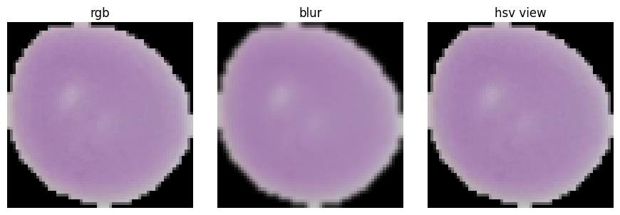

```python
# gaussian blurring on test data
x_test_blur = gaussian_blur_batch(x_test, ksize=(3,3), sigma=0)
print('test blur shape:', x_test_blur.shape,
      'min max:', float(x_test_blur.min()), float(x_test_blur.max()))

# compare rgb vs blur vs hsv view for a single sample
def show_rgb_blur_hsv(x_rgb, x_blur, x_hsv, i=None):
    if i is None:
        i = np.random.randint(len(x_rgb))
    hsv_as_rgb = cv2.cvtColor(x_hsv[i].astype(np.float32), cv2.COLOR_HSV2RGB)
    fig, ax = plt.subplots(1,3, figsize=(9,3))
    ax[0].imshow(x_rgb[i]);      ax[0].axis('off'); ax[0].set_title('rgb')
    ax[1].imshow(x_blur[i]);     ax[1].axis('off'); ax[1].set_title('blur')
    ax[2].imshow(hsv_as_rgb);    ax[2].axis('off'); ax[2].set_title('hsv view')
    plt.tight_layout(); plt.show()

show_rgb_blur_hsv(x_train, x_train_blur, x_train_hsv)
```

#### **Observations and insights: _____**

**Think About It:** Would blurring help us for this problem statement in any way? What else can we try?

Applying a light Gaussian blur reduces high-frequency noise but also softens the boundaries of parasites. Overuse could impair feature clarity, so Gaussian blurring is better reserved for selective augmentation to improve robustness to focus variation, rather than as a fixed preprocessing step.

## **Model Building**

### **Importing the required libraries for building and training our Model**

```python
# importing the required libraries for building and training our model
import tensorflow as tf
from tensorflow.keras import layers, models
from tensorflow.keras.optimizers import Adam
from tensorflow.keras.callbacks import EarlyStopping, ModelCheckpoint, ReduceLROnPlateau
from tensorflow.keras.utils import to_categorical
import numpy as np
import matplotlib.pyplot as plt
import seaborn as sns
from sklearn.metrics import confusion_matrix, classification_report
```

#### **One Hot Encoding the train and test labels**

```python
# one hot encoding the train and test labels
num_classes = 2
y_train_oh = y_train if y_train.ndim == 2 else to_categorical(y_train, num_classes=num_classes)
y_test_oh  = y_test  if y_test.ndim  == 2 else to_categorical(y_test,  num_classes=num_classes)

print('y shapes one hot:', y_train_oh.shape, y_test_oh.shape)
```

```
y shapes one hot: (24958, 2) (2600, 2)
```

### **Building the model**

```python
# build base model correctly
from tensorflow.keras import layers, models

def build_base_cnn(input_shape=(64,64,3), num_classes=2):
    m = models.Sequential(name='base_cnn')
    m.add(layers.Input(shape=input_shape))
    m.add(layers.Conv2D(32, (3,3), padding='same', activation='relu'))
    m.add(layers.MaxPooling2D(2,2))
    m.add(layers.Conv2D(64, (3,3), padding='same', activation='relu'))
    m.add(layers.MaxPooling2D(2,2))
    m.add(layers.Flatten())
    m.add(layers.Dropout(0.3))
    m.add(layers.Dense(64, activation='relu'))
    m.add(layers.Dense(num_classes, activation='softmax'))
    return m
```

### **Compiling the model**

```python
base_model = build_base_cnn(input_shape=x_train.shape[1:], num_classes=2)

from tensorflow.keras.optimizers import Adam
import tensorflow as tf
base_model.compile(optimizer=Adam(1e-3),
                   loss='categorical_crossentropy',
                   metrics=['accuracy', tf.keras.metrics.AUC(name='auc')])
base_model.summary()
```

```
Model: "base_cnn"
```

```
┏━━━━━━━━━━━━━━━━━━━━━━━━━━━━━━━━━┳━━━━━━━━━━━━━━━━━━━━━━━━┳━━━━━━━━━━━━━━━┓
┃ Layer (type)                    ┃ Output Shape           ┃       Param # ┃
┡━━━━━━━━━━━━━━━━━━━━━━━━━━━━━━━━━╇━━━━━━━━━━━━━━━━━━━━━━━━╇━━━━━━━━━━━━━━━┩
│ conv2d (Conv2D)                 │ (None, 64, 64, 32)     │           896 │
├─────────────────────────────────┼────────────────────────┼───────────────┤
│ max_pooling2d (MaxPooling2D)    │ (None, 32, 32, 32)     │             0 │
├─────────────────────────────────┼────────────────────────┼───────────────┤
│ conv2d_1 (Conv2D)               │ (None, 32, 32, 64)     │        18,496 │
├─────────────────────────────────┼────────────────────────┼───────────────┤
│ max_pooling2d_1 (MaxPooling2D)  │ (None, 16, 16, 64)     │             0 │
├─────────────────────────────────┼────────────────────────┼───────────────┤
│ flatten (Flatten)               │ (None, 16384)          │             0 │
├─────────────────────────────────┼────────────────────────┼───────────────┤
│ dropout (Dropout)               │ (None, 16384)          │             0 │
├─────────────────────────────────┼────────────────────────┼───────────────┤
│ dense (Dense)                   │ (None, 64)             │     1,048,640 │
├─────────────────────────────────┼────────────────────────┼───────────────┤
│ dense_1 (Dense)                 │ (None, 2)              │           130 │
└─────────────────────────────────┴────────────────────────┴───────────────┘
```

```
 Total params: 1,068,162 (4.07 MB)
```

```
 Trainable params: 1,068,162 (4.07 MB)
```

```
 Non-trainable params: 0 (0.00 B)
```

**Using Callbacks**

```python
from tensorflow.keras.callbacks import EarlyStopping, ModelCheckpoint, ReduceLROnPlateau

cbs = [
    EarlyStopping(monitor='val_loss', patience=2, min_delta=1e-3, restore_best_weights=True),
    ModelCheckpoint('best_base_cnn.keras', monitor='val_loss', save_best_only=True, verbose=1),
    ReduceLROnPlateau(monitor='val_loss', factor=0.5, patience=1, min_lr=1e-6, verbose=1)
]
```

**Fit and train our Model**

```python
# fit and train our model
history_base = base_model.fit(
    x_train, y_train_oh,
    validation_split=0.2,
    epochs=20,
    batch_size=128,
    callbacks=cbs,
    verbose=1
)
```

```
156/156 ━━━━━━━━━━━━━━━━━━━━ 0s 34ms/step - accuracy: 0.5761 - auc: 0.6021 - loss: 0.6915
Epoch 1: val_loss improved from inf to 1.31478, saving model to best_base_cnn.keras
156/156 ━━━━━━━━━━━━━━━━━━━━ 15s 46ms/step - accuracy: 0.5763 - auc: 0.6026 - loss: 0.6912 - val_accuracy: 0.0000e+00 - val_auc: 8.0261e-08 - val_loss: 1.3148 - learning_rate: 0.0010
155/156 ━━━━━━━━━━━━━━━━━━━━ 0s 5ms/step - accuracy: 0.6894 - auc: 0.7826 - loss: 0.5655
Epoch 2: val_loss improved from 1.31478 to 0.88952, saving model to best_base_cnn.keras
156/156 ━━━━━━━━━━━━━━━━━━━━ 1s 7ms/step - accuracy: 0.6899 - auc: 0.7829 - loss: 0.5652 - val_accuracy: 0.7384 - val_auc: 0.7382 - val_loss: 0.8895 - learning_rate: 0.0010
151/156 ━━━━━━━━━━━━━━━━━━━━ 0s 5ms/step - accuracy: 0.8697 - auc: 0.9378 - loss: 0.3986
Epoch 3: val_loss improved from 0.88952 to 0.35881, saving model to best_base_cnn.keras
156/156 ━━━━━━━━━━━━━━━━━━━━ 1s 7ms/step - accuracy: 0.8703 - auc: 0.9382 - loss: 0.3965 - val_accuracy: 0.9617 - val_auc: 0.9787 - val_loss: 0.3588 - learning_rate: 0.0010
149/156 ━━━━━━━━━━━━━━━━━━━━ 0s 5ms/step - accuracy: 0.9098 - auc: 0.9675 - loss: 0.2745
Epoch 4: val_loss did not improve from 0.35881

Epoch 4: ReduceLROnPlateau reducing learning rate to 0.0005000000237487257.
156/156 ━━━━━━━━━━━━━━━━━━━━ 1s 7ms/step - accuracy: 0.9101 - auc: 0.9677 - loss: 0.2733 - val_accuracy: 0.9271 - val_auc: 0.9418 - val_loss: 0.4878 - learning_rate: 0.0010
148/156 ━━━━━━━━━━━━━━━━━━━━ 0s 5ms/step - accuracy: 0.9412 - auc: 0.9849 - loss: 0.1877
Epoch 5: val_loss improved from 0.35881 to 0.19159, saving model to best_base_cnn.keras
156/156 ━━━━━━━━━━━━━━━━━━━━ 1s 7ms/step - accuracy: 0.9411 - auc: 0.9849 - loss: 0.1873 - val_accuracy: 0.9724 - val_auc: 0.9881 - val_loss: 0.1916 - learning_rate: 5.0000e-04
156/156 ━━━━━━━━━━━━━━━━━━━━ 0s 5ms/step - accuracy: 0.9448 - auc: 0.9872 - loss: 0.1588
Epoch 6: val_loss did not improve from 0.19159

Epoch 6: ReduceLROnPlateau reducing learning rate to 0.0002500000118743628.
156/156 ━━━━━━━━━━━━━━━━━━━━ 1s 7ms/step - accuracy: 0.9448 - auc: 0.9872 - loss: 0.1588 - val_accuracy: 0.9653 - val_auc: 0.9859 - val_loss: 0.2071 - learning_rate: 5.0000e-04
150/156 ━━━━━━━━━━━━━━━━━━━━ 0s 5ms/step - accuracy: 0.9537 - auc: 0.9907 - loss: 0.1389
Epoch 7: val_loss improved from 0.19159 to 0.18869, saving model to best_base_cnn.keras
156/156 ━━━━━━━━━━━━━━━━━━━━ 1s 7ms/step - accuracy: 0.9537 - auc: 0.9907 - loss: 0.1388 - val_accuracy: 0.9712 - val_auc: 0.9875 - val_loss: 0.1887 - learning_rate: 2.5000e-04
150/156 ━━━━━━━━━━━━━━━━━━━━ 0s 5ms/step - accuracy: 0.9558 - auc: 0.9917 - loss: 0.1293
Epoch 8: val_loss did not improve from 0.18869

Epoch 8: ReduceLROnPlateau reducing learning rate to 0.0001250000059371814.
156/156 ━━━━━━━━━━━━━━━━━━━━ 1s 7ms/step - accuracy: 0.9558 - auc: 0.9917 - loss: 0.1292 - val_accuracy: 0.9563 - val_auc: 0.9778 - val_loss: 0.2462 - learning_rate: 2.5000e-04
149/156 ━━━━━━━━━━━━━━━━━━━━ 0s 5ms/step - accuracy: 0.9611 - auc: 0.9930 - loss: 0.1244
Epoch 9: val_loss improved from 0.18869 to 0.15883, saving model to best_base_cnn.keras
156/156 ━━━━━━━━━━━━━━━━━━━━ 1s 7ms/step - accuracy: 0.9611 - auc: 0.9930 - loss: 0.1241 - val_accuracy: 0.9754 - val_auc: 0.9889 - val_loss: 0.1588 - learning_rate: 1.2500e-04
147/156 ━━━━━━━━━━━━━━━━━━━━ 0s 5ms/step - accuracy: 0.9606 - auc: 0.9938 - loss: 0.1107
Epoch 10: val_loss improved from 0.15883 to 0.13166, saving model to best_base_cnn.keras
156/156 ━━━━━━━━━━━━━━━━━━━━ 1s 7ms/step - accuracy: 0.9606 - auc: 0.9937 - loss: 0.1108 - val_accuracy: 0.9814 - val_auc: 0.9922 - val_loss: 0.1317 - learning_rate: 1.2500e-04
155/156 ━━━━━━━━━━━━━━━━━━━━ 0s 6ms/step - accuracy: 0.9619 - auc: 0.9940 - loss: 0.1071
Epoch 11: val_loss did not improve from 0.13166

Epoch 11: ReduceLROnPlateau reducing learning rate to 6.25000029685907e-05.
156/156 ━━━━━━━━━━━━━━━━━━━━ 1s 7ms/step - accuracy: 0.9619 - auc: 0.9940 - loss: 0.1071 - val_accuracy: 0.9681 - val_auc: 0.9852 - val_loss: 0.1705 - learning_rate: 1.2500e-04
149/156 ━━━━━━━━━━━━━━━━━━━━ 0s 5ms/step - accuracy: 0.9642 - auc: 0.9941 - loss: 0.1032
Epoch 12: val_loss did not improve from 0.13166

Epoch 12: ReduceLROnPlateau reducing learning rate to 3.125000148429535e-05.
156/156 ━━━━━━━━━━━━━━━━━━━━ 1s 7ms/step - accuracy: 0.9643 - auc: 0.9941 - loss: 0.1032 - val_accuracy: 0.9744 - val_auc: 0.9893 - val_loss: 0.1536 - learning_rate: 6.2500e-05
```

### **Evaluating the model on test data**

```python
# find best epoch
import numpy as np
h = history_base.history
best_ep = int(np.argmin(h['val_loss'])) + 1
print('best epoch:', best_ep,
      'val_loss:', h['val_loss'][best_ep-1],
      'val_acc:', h['val_accuracy'][best_ep-1])

# load best model and evaluate on test
import tensorflow as tf
best_model = tf.keras.models.load_model('best_base_cnn.keras')

test_loss, test_acc, test_auc = best_model.evaluate(x_test, y_test_oh, verbose=0)
print('test loss:', round(test_loss,4),
      'test acc:', round(test_acc,4),
      'test auc:', round(test_auc,4))

# predictions and report
from sklearn.metrics import classification_report

y_prob = best_model.predict(x_test, batch_size=128, verbose=0)
y_pred = np.argmax(y_prob, axis=1)
y_true = y_test if y_test.ndim == 1 else np.argmax(y_test, axis=1)

idx_to_class = {v:k for k,v in class_map.items()}
target_names = [idx_to_class[i] for i in range(len(idx_to_class))]

print(classification_report(y_true, y_pred, target_names=target_names))
```

```
best epoch: 10 val_loss: 0.13166281580924988 val_acc: 0.981370210647583
test loss: 0.1301 test acc: 0.9577 test auc: 0.9924
              precision    recall  f1-score   support

 parasitized       0.98      0.94      0.96      1300
  uninfected       0.94      0.98      0.96      1300

    accuracy                           0.96      2600
   macro avg       0.96      0.96      0.96      2600
weighted avg       0.96      0.96      0.96      2600
```

**Plotting the confusion matrix**

```
classification report
              precision    recall  f1-score   support

 parasitized       0.98      0.94      0.96      1300
  uninfected       0.94      0.98      0.96      1300

    accuracy                           0.96      2600
   macro avg       0.96      0.96      0.96      2600
weighted avg       0.96      0.96      0.96      2600
```

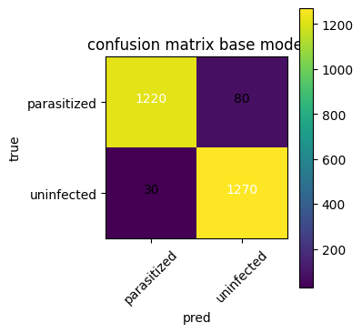

```python
# preds confusion matrix and report
import numpy as np, matplotlib.pyplot as plt
from sklearn.metrics import confusion_matrix, classification_report

y_true = y_test if y_test.ndim == 1 else np.argmax(y_test, axis=1)
y_pred = np.argmax(best_model.predict(x_test, batch_size=128, verbose=0), axis=1)

cm = confusion_matrix(y_true, y_pred)
print('classification report')
idx_to_class = {v:k for k,v in class_map.items()}
target_names = [idx_to_class[i] for i in range(len(idx_to_class))]
print(classification_report(y_true, y_pred, target_names=target_names))

plt.figure(figsize=(4,4))
plt.imshow(cm, interpolation='nearest')
plt.title('confusion matrix base model')
plt.colorbar()
ticks = np.arange(len(target_names))
plt.xticks(ticks, target_names, rotation=45)
plt.yticks(ticks, target_names)
thr = cm.max() / 2.0
for i in range(cm.shape[0]):
    for j in range(cm.shape[1]):
        plt.text(j, i, cm[i, j], ha='center',
                 color='white' if cm[i, j] > thr else 'black', fontsize=10)
plt.ylabel('true'); plt.xlabel('pred'); plt.tight_layout(); plt.show()
```

**Plotting the train and validation curves**

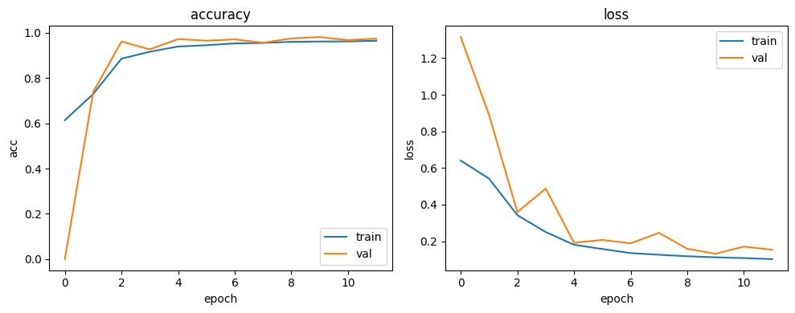

```python
# plotting the train and validation curves
def plot_history(h):
    plt.figure(figsize=(10,4))
    # accuracy
    plt.subplot(1,2,1)
    plt.plot(h.history['accuracy'], label='train')
    plt.plot(h.history['val_accuracy'], label='val')
    plt.title('accuracy')
    plt.xlabel('epoch')
    plt.ylabel('acc')
    plt.legend()
    # loss
    plt.subplot(1,2,2)
    plt.plot(h.history['loss'], label='train')
    plt.plot(h.history['val_loss'], label='val')
    plt.title('loss')
    plt.xlabel('epoch')
    plt.ylabel('loss')
    plt.legend()
    plt.tight_layout()
    plt.show()

plot_history(history_base)
```

So now let's try to build another model with few more add on layers and try to check if we can try to improve the model. Therefore try to build a model by adding few layers if required and altering the activation functions.

### **Model 1**

#### **Trying to improve the performance of our model by adding new layers**

```python
# model 1  add layers

from tensorflow.keras import layers, models
from tensorflow.keras.optimizers import Adam
from tensorflow.keras.callbacks import EarlyStopping, ModelCheckpoint, ReduceLROnPlateau
from tensorflow.keras.utils import to_categorical
import numpy as np
import matplotlib.pyplot as plt
from sklearn.metrics import confusion_matrix, classification_report

# labels
num_classes = 2
y_train_oh = y_train if y_train.ndim == 2 else to_categorical(y_train, num_classes)
y_test_oh  = y_test  if y_test.ndim  == 2 else to_categorical(y_test,  num_classes)
idx_to_class = {v:k for k,v in class_map.items()}
target_names = [idx_to_class[i] for i in range(len(idx_to_class))]
```

### **Building the Model**

```python
# model 1  no warning
def build_model1(input_shape=(64,64,3), num_classes=2):
    m = models.Sequential(name='model1')
    m.add(layers.Input(shape=input_shape))
    m.add(layers.Conv2D(32, (3,3), padding='same', activation='relu'))
    m.add(layers.MaxPooling2D(2,2))

    m.add(layers.Conv2D(64, (3,3), padding='same', activation='relu'))
    m.add(layers.MaxPooling2D(2,2))

    m.add(layers.Conv2D(128, (3,3), padding='same', activation='relu'))
    m.add(layers.MaxPooling2D(2,2))

    m.add(layers.Flatten())
    m.add(layers.Dropout(0.4))
    m.add(layers.Dense(128, activation='relu'))
    m.add(layers.Dropout(0.3))
    m.add(layers.Dense(num_classes, activation='softmax'))
    return m
```

### **Compiling the model**

```python
# build model1
try:
    model1
except NameError:
    model1 = build_model1(input_shape=x_train.shape[1:], num_classes=2)

# compile
from tensorflow.keras.optimizers import Adam
model1.compile(optimizer=Adam(1e-3),
               loss='categorical_crossentropy',
               metrics=['accuracy'])
model1.summary()
```

```
Model: "model1"
```

```
┏━━━━━━━━━━━━━━━━━━━━━━━━━━━━━━━━━┳━━━━━━━━━━━━━━━━━━━━━━━━┳━━━━━━━━━━━━━━━┓
┃ Layer (type)                    ┃ Output Shape           ┃       Param # ┃
┡━━━━━━━━━━━━━━━━━━━━━━━━━━━━━━━━━╇━━━━━━━━━━━━━━━━━━━━━━━━╇━━━━━━━━━━━━━━━┩
│ conv2d_2 (Conv2D)               │ (None, 64, 64, 32)     │           896 │
├─────────────────────────────────┼────────────────────────┼───────────────┤
│ max_pooling2d_2 (MaxPooling2D)  │ (None, 32, 32, 32)     │             0 │
├─────────────────────────────────┼────────────────────────┼───────────────┤
│ conv2d_3 (Conv2D)               │ (None, 32, 32, 64)     │        18,496 │
├─────────────────────────────────┼────────────────────────┼───────────────┤
│ max_pooling2d_3 (MaxPooling2D)  │ (None, 16, 16, 64)     │             0 │
├─────────────────────────────────┼────────────────────────┼───────────────┤
│ conv2d_4 (Conv2D)               │ (None, 16, 16, 128)    │        73,856 │
├─────────────────────────────────┼────────────────────────┼───────────────┤
│ max_pooling2d_4 (MaxPooling2D)  │ (None, 8, 8, 128)      │             0 │
├─────────────────────────────────┼────────────────────────┼───────────────┤
│ flatten_1 (Flatten)             │ (None, 8192)           │             0 │
├─────────────────────────────────┼────────────────────────┼───────────────┤
│ dropout_1 (Dropout)             │ (None, 8192)           │             0 │
├─────────────────────────────────┼────────────────────────┼───────────────┤
│ dense_2 (Dense)                 │ (None, 128)            │     1,048,704 │
├─────────────────────────────────┼────────────────────────┼───────────────┤
│ dropout_2 (Dropout)             │ (None, 128)            │             0 │
├─────────────────────────────────┼────────────────────────┼───────────────┤
│ dense_3 (Dense)                 │ (None, 2)              │           258 │
└─────────────────────────────────┴────────────────────────┴───────────────┘
```

```
 Total params: 1,142,210 (4.36 MB)
```

```
 Trainable params: 1,142,210 (4.36 MB)
```

```
 Non-trainable params: 0 (0.00 B)
```

**Using Callbacks**

```python
# using callbacks
from tensorflow.keras.callbacks import EarlyStopping, ModelCheckpoint, ReduceLROnPlateau

cbs1 = [
    EarlyStopping(monitor='val_loss', patience=3, min_delta=1e-3, restore_best_weights=True),
    ModelCheckpoint('model1_best.keras', monitor='val_loss', save_best_only=True, verbose=1),
    ReduceLROnPlateau(monitor='val_loss', factor=0.5, patience=2, min_lr=1e-6, verbose=1)
]
```

**Fit and Train the model**

```python
hist1 = model1.fit(
    x_train, y_train_oh,
    validation_split=0.2,
    epochs=25,
    batch_size=128,
    callbacks=cbs1,
    verbose=1
)
```

```
156/156 ━━━━━━━━━━━━━━━━━━━━ 0s 31ms/step - accuracy: 0.6343 - loss: 0.6630
Epoch 1: val_loss improved from inf to 0.29483, saving model to model1_best.keras
156/156 ━━━━━━━━━━━━━━━━━━━━ 13s 46ms/step - accuracy: 0.6348 - loss: 0.6624 - val_accuracy: 0.9123 - val_loss: 0.2948 - learning_rate: 0.0010
152/156 ━━━━━━━━━━━━━━━━━━━━ 0s 6ms/step - accuracy: 0.9211 - loss: 0.1985
Epoch 2: val_loss improved from 0.29483 to 0.11696, saving model to model1_best.keras
156/156 ━━━━━━━━━━━━━━━━━━━━ 1s 8ms/step - accuracy: 0.9218 - loss: 0.1968 - val_accuracy: 0.9679 - val_loss: 0.1170 - learning_rate: 0.0010
154/156 ━━━━━━━━━━━━━━━━━━━━ 0s 6ms/step - accuracy: 0.9724 - loss: 0.0825
Epoch 3: val_loss improved from 0.11696 to 0.07215, saving model to model1_best.keras
156/156 ━━━━━━━━━━━━━━━━━━━━ 1s 8ms/step - accuracy: 0.9724 - loss: 0.0825 - val_accuracy: 0.9864 - val_loss: 0.0722 - learning_rate: 0.0010
154/156 ━━━━━━━━━━━━━━━━━━━━ 0s 6ms/step - accuracy: 0.9779 - loss: 0.0693
Epoch 4: val_loss did not improve from 0.07215
156/156 ━━━━━━━━━━━━━━━━━━━━ 1s 7ms/step - accuracy: 0.9779 - loss: 0.0693 - val_accuracy: 0.9834 - val_loss: 0.0756 - learning_rate: 0.0010
154/156 ━━━━━━━━━━━━━━━━━━━━ 0s 6ms/step - accuracy: 0.9793 - loss: 0.0586
Epoch 5: val_loss improved from 0.07215 to 0.04284, saving model to model1_best.keras
156/156 ━━━━━━━━━━━━━━━━━━━━ 1s 8ms/step - accuracy: 0.9793 - loss: 0.0586 - val_accuracy: 0.9924 - val_loss: 0.0428 - learning_rate: 0.0010
154/156 ━━━━━━━━━━━━━━━━━━━━ 0s 6ms/step - accuracy: 0.9814 - loss: 0.0571
Epoch 6: val_loss did not improve from 0.04284
156/156 ━━━━━━━━━━━━━━━━━━━━ 1s 7ms/step - accuracy: 0.9814 - loss: 0.0570 - val_accuracy: 0.9844 - val_loss: 0.0621 - learning_rate: 0.0010
154/156 ━━━━━━━━━━━━━━━━━━━━ 0s 6ms/step - accuracy: 0.9831 - loss: 0.0497
Epoch 7: val_loss did not improve from 0.04284

Epoch 7: ReduceLROnPlateau reducing learning rate to 0.0005000000237487257.
156/156 ━━━━━━━━━━━━━━━━━━━━ 1s 7ms/step - accuracy: 0.9831 - loss: 0.0498 - val_accuracy: 0.9772 - val_loss: 0.0912 - learning_rate: 0.0010
154/156 ━━━━━━━━━━━━━━━━━━━━ 0s 6ms/step - accuracy: 0.9838 - loss: 0.0450
Epoch 8: val_loss did not improve from 0.04284
156/156 ━━━━━━━━━━━━━━━━━━━━ 1s 7ms/step - accuracy: 0.9838 - loss: 0.0450 - val_accuracy: 0.9760 - val_loss: 0.0909 - learning_rate: 5.0000e-04
```

### **Evaluating the model**

```python
# evaluating the model

y_prob1 = model1.predict(x_test, batch_size=128, verbose=0)
y_pred1 = np.argmax(y_prob1, axis=1)
y_true  = y_test if y_test.ndim == 1 else np.argmax(y_test, axis=1)

print('classification report model1')
print(classification_report(y_true, y_pred1, target_names=target_names))
```

```
classification report model1
              precision    recall  f1-score   support

 parasitized       0.99      0.97      0.98      1300
  uninfected       0.97      0.99      0.98      1300

    accuracy                           0.98      2600
   macro avg       0.98      0.98      0.98      2600
weighted avg       0.98      0.98      0.98      2600
```

**Plotting the confusion matrix**

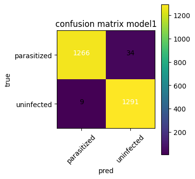

```python
# plotting the confusion matrix

cm1 = confusion_matrix(y_true, y_pred1)
plt.figure(figsize=(4,4))
plt.imshow(cm1, interpolation='nearest')
plt.title('confusion matrix model1')
plt.colorbar()
tick_marks = np.arange(len(target_names))
plt.xticks(tick_marks, target_names, rotation=45)
plt.yticks(tick_marks, target_names)
thresh = cm1.max() / 2.0
for i in range(cm1.shape[0]):
    for j in range(cm1.shape[1]):
        plt.text(j, i, cm1[i, j], horizontalalignment='center',
                 color='white' if cm1[i, j] > thresh else 'black', fontsize=10)
plt.ylabel('true')
plt.xlabel('pred')
plt.tight_layout()
plt.show()
```

**Plotting the train and the validation curves**

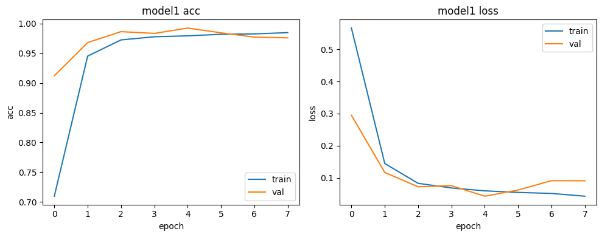

```python
# plotting the train and the validation curves

def plot_hist(h, title='model'):
    plt.figure(figsize=(10,4))
    plt.subplot(1,2,1)
    plt.plot(h.history['accuracy'], label='train')
    plt.plot(h.history['val_accuracy'], label='val')
    plt.title(f'{title} acc')
    plt.xlabel('epoch'); plt.ylabel('acc'); plt.legend()

    plt.subplot(1,2,2)
    plt.plot(h.history['loss'], label='train')
    plt.plot(h.history['val_loss'], label='val')
    plt.title(f'{title} loss')
    plt.xlabel('epoch'); plt.ylabel('loss'); plt.legend()
    plt.tight_layout(); plt.show()

plot_hist(hist1, title='model1')
```

### **Think about it:**

Now let's build a model with LeakyRelu as the activation function

- Can the model performance be improved if we change our activation function to LeakyRelu?
- Can BatchNormalization improve our model?

Let us try to build a model using BatchNormalization and using LeakyRelu as our activation function.

### **Model 2 with Batch Normalization**

```python
# model 2 with batch normalization and leaky relu
# prep labels and names
import numpy as np
from tensorflow.keras.utils import to_categorical

num_classes = 2
y_train_oh = y_train if y_train.ndim == 2 else to_categorical(y_train, num_classes)
y_test_oh  = y_test  if y_test.ndim  == 2 else to_categorical(y_test,  num_classes)
idx_to_class = {v:k for k,v in class_map.items()}
target_names = [idx_to_class[i] for i in range(len(idx_to_class))]
```

### **Building the Model**

```python
# building the model
from tensorflow.keras import layers, models
from tensorflow.keras.layers import BatchNormalization, LeakyReLU, GlobalAveragePooling2D, Input

def build_model2(input_shape=(64,64,3), num_classes=2):
    inp = Input(shape=input_shape)
    x = layers.Conv2D(32, (3,3), padding='same')(inp)
    x = BatchNormalization()(x)
    x = LeakyReLU(negative_slope=0.1)(x)
    x = layers.MaxPooling2D(2,2)(x)

    x = layers.Conv2D(64, (3,3), padding='same')(x)
    x = BatchNormalization()(x)
    x = LeakyReLU(negative_slope=0.1)(x)
    x = layers.MaxPooling2D(2,2)(x)

    x = layers.Conv2D(128, (3,3), padding='same')(x)
    x = BatchNormalization()(x)
    x = LeakyReLU(negative_slope=0.1)(x)
    x = layers.MaxPooling2D(2,2)(x)

    x = GlobalAveragePooling2D()(x)
    x = layers.Dropout(0.4)(x)
    x = layers.Dense(128)(x)
    x = LeakyReLU(negative_slope=0.1)(x)
    x = layers.Dropout(0.3)(x)
    out = layers.Dense(num_classes, activation='softmax')(x)
    m = models.Model(inp, out, name='model2_bn_lrelu')
    return m

model2 = build_model2(input_shape=x_train.shape[1:], num_classes=num_classes)
model2.summary()
```

```
Model: "model2_bn_lrelu"
```

```
┏━━━━━━━━━━━━━━━━━━━━━━━━━━━━━━━━━┳━━━━━━━━━━━━━━━━━━━━━━━━┳━━━━━━━━━━━━━━━┓
┃ Layer (type)                    ┃ Output Shape           ┃       Param # ┃
┡━━━━━━━━━━━━━━━━━━━━━━━━━━━━━━━━━╇━━━━━━━━━━━━━━━━━━━━━━━━╇━━━━━━━━━━━━━━━┩
│ input_layer_2 (InputLayer)      │ (None, 64, 64, 3)      │             0 │
├─────────────────────────────────┼────────────────────────┼───────────────┤
│ conv2d_5 (Conv2D)               │ (None, 64, 64, 32)     │           896 │
├─────────────────────────────────┼────────────────────────┼───────────────┤
│ batch_normalization             │ (None, 64, 64, 32)     │           128 │
│ (BatchNormalization)            │                        │               │
├─────────────────────────────────┼────────────────────────┼───────────────┤
│ leaky_re_lu (LeakyReLU)         │ (None, 64, 64, 32)     │             0 │
├─────────────────────────────────┼────────────────────────┼───────────────┤
│ max_pooling2d_5 (MaxPooling2D)  │ (None, 32, 32, 32)     │             0 │
├─────────────────────────────────┼────────────────────────┼───────────────┤
│ conv2d_6 (Conv2D)               │ (None, 32, 32, 64)     │        18,496 │
├─────────────────────────────────┼────────────────────────┼───────────────┤
│ batch_normalization_1           │ (None, 32, 32, 64)     │           256 │
│ (BatchNormalization)            │                        │               │
├─────────────────────────────────┼────────────────────────┼───────────────┤
│ leaky_re_lu_1 (LeakyReLU)       │ (None, 32, 32, 64)     │             0 │
├─────────────────────────────────┼────────────────────────┼───────────────┤
│ max_pooling2d_6 (MaxPooling2D)  │ (None, 16, 16, 64)     │             0 │
├─────────────────────────────────┼────────────────────────┼───────────────┤
│ conv2d_7 (Conv2D)               │ (None, 16, 16, 128)    │        73,856 │
├─────────────────────────────────┼────────────────────────┼───────────────┤
│ batch_normalization_2           │ (None, 16, 16, 128)    │           512 │
│ (BatchNormalization)            │                        │               │
├─────────────────────────────────┼────────────────────────┼───────────────┤
│ leaky_re_lu_2 (LeakyReLU)       │ (None, 16, 16, 128)    │             0 │
├─────────────────────────────────┼────────────────────────┼───────────────┤
│ max_pooling2d_7 (MaxPooling2D)  │ (None, 8, 8, 128)      │             0 │
├─────────────────────────────────┼────────────────────────┼───────────────┤
│ global_average_pooling2d        │ (None, 128)            │             0 │
│ (GlobalAveragePooling2D)        │                        │               │
├─────────────────────────────────┼────────────────────────┼───────────────┤
│ dropout_3 (Dropout)             │ (None, 128)            │             0 │
├─────────────────────────────────┼────────────────────────┼───────────────┤
│ dense_4 (Dense)                 │ (None, 128)            │        16,512 │
├─────────────────────────────────┼────────────────────────┼───────────────┤
│ leaky_re_lu_3 (LeakyReLU)       │ (None, 128)            │             0 │
├─────────────────────────────────┼────────────────────────┼───────────────┤
│ dropout_4 (Dropout)             │ (None, 128)            │             0 │
├─────────────────────────────────┼────────────────────────┼───────────────┤
│ dense_5 (Dense)                 │ (None, 2)              │           258 │
└─────────────────────────────────┴────────────────────────┴───────────────┘
```

```
 Total params: 110,914 (433.26 KB)
```

```
 Trainable params: 110,466 (431.51 KB)
```

```
 Non-trainable params: 448 (1.75 KB)
```

### **Compiling the model**

```python
# compiling the model
from tensorflow.keras.optimizers import Adam
model2.compile(optimizer=Adam(1e-3),
               loss='categorical_crossentropy',
               metrics=['accuracy'])
```

**Using callbacks**

```python
# using callbacks
from tensorflow.keras.callbacks import EarlyStopping, ModelCheckpoint, ReduceLROnPlateau

cbs2 = [
    EarlyStopping(monitor='val_loss', patience=2, min_delta=1e-3, restore_best_weights=True),
    ModelCheckpoint('model2_best.keras', monitor='val_loss', save_best_only=True, verbose=1),
    ReduceLROnPlateau(monitor='val_loss', factor=0.5, patience=1, min_lr=1e-6, verbose=1)
]
```

**Fit and train the model**

```python
# make tf data splits for speed
from sklearn.model_selection import train_test_split
import tensorflow as tf
y_train_int = y_train if y_train.ndim == 1 else y_train.argmax(1)

x_tr, x_va, y_tr, y_va = train_test_split(
    x_train, y_train_oh, test_size=0.2, stratify=y_train_int, random_state=42
)

bs = 128
train_ds = tf.data.Dataset.from_tensor_slices((x_tr, y_tr)).shuffle(8192).batch(bs).prefetch(tf.data.AUTOTUNE)
val_ds   = tf.data.Dataset.from_tensor_slices((x_va, y_va)).batch(bs).prefetch(tf.data.AUTOTUNE)

# fit and train the model
hist2 = model2.fit(
    train_ds,
    validation_data=val_ds,
    epochs=20,
    callbacks=cbs2,
    verbose=1
)

# fit and train the model
hist2 = model2.fit(
    train_ds,
    validation_data=val_ds,
    epochs=20,
    callbacks=cbs2,
    verbose=1
)
```

```
156/156 ━━━━━━━━━━━━━━━━━━━━ 0s 29ms/step - accuracy: 0.7101 - loss: 0.5855
Epoch 1: val_loss improved from inf to 1.46229, saving model to model2_best.keras
156/156 ━━━━━━━━━━━━━━━━━━━━ 14s 46ms/step - accuracy: 0.7108 - loss: 0.5843 - val_accuracy: 0.4958 - val_loss: 1.4623 - learning_rate: 0.0010
151/156 ━━━━━━━━━━━━━━━━━━━━ 0s 7ms/step - accuracy: 0.9467 - loss: 0.1542
Epoch 2: val_loss improved from 1.46229 to 0.96630, saving model to model2_best.keras
156/156 ━━━━━━━━━━━━━━━━━━━━ 1s 8ms/step - accuracy: 0.9468 - loss: 0.1539 - val_accuracy: 0.5958 - val_loss: 0.9663 - learning_rate: 0.0010
153/156 ━━━━━━━━━━━━━━━━━━━━ 0s 7ms/step - accuracy: 0.9628 - loss: 0.1128
Epoch 3: val_loss did not improve from 0.96630

Epoch 3: ReduceLROnPlateau reducing learning rate to 0.0005000000237487257.
156/156 ━━━━━━━━━━━━━━━━━━━━ 1s 8ms/step - accuracy: 0.9628 - loss: 0.1127 - val_accuracy: 0.5126 - val_loss: 1.6059 - learning_rate: 0.0010
153/156 ━━━━━━━━━━━━━━━━━━━━ 0s 7ms/step - accuracy: 0.9686 - loss: 0.0948
Epoch 4: val_loss did not improve from 0.96630

Epoch 4: ReduceLROnPlateau reducing learning rate to 0.0002500000118743628.
156/156 ━━━━━━━━━━━━━━━━━━━━ 1s 8ms/step - accuracy: 0.9686 - loss: 0.0948 - val_accuracy: 0.5461 - val_loss: 2.1685 - learning_rate: 5.0000e-04
153/156 ━━━━━━━━━━━━━━━━━━━━ 0s 7ms/step - accuracy: 0.9654 - loss: 0.1042
Epoch 1: val_loss improved from 0.96630 to 0.13148, saving model to model2_best.keras
156/156 ━━━━━━━━━━━━━━━━━━━━ 1s 8ms/step - accuracy: 0.9654 - loss: 0.1041 - val_accuracy: 0.9515 - val_loss: 0.1315 - learning_rate: 2.5000e-04
153/156 ━━━━━━━━━━━━━━━━━━━━ 0s 7ms/step - accuracy: 0.9698 - loss: 0.0918
Epoch 2: val_loss improved from 0.13148 to 0.10006, saving model to model2_best.keras
156/156 ━━━━━━━━━━━━━━━━━━━━ 1s 8ms/step - accuracy: 0.9698 - loss: 0.0918 - val_accuracy: 0.9659 - val_loss: 0.1001 - learning_rate: 2.5000e-04
153/156 ━━━━━━━━━━━━━━━━━━━━ 0s 7ms/step - accuracy: 0.9692 - loss: 0.0897
Epoch 3: val_loss improved from 0.10006 to 0.09079, saving model to model2_best.keras
156/156 ━━━━━━━━━━━━━━━━━━━━ 1s 8ms/step - accuracy: 0.9692 - loss: 0.0897 - val_accuracy: 0.9698 - val_loss: 0.0908 - learning_rate: 2.5000e-04
153/156 ━━━━━━━━━━━━━━━━━━━━ 0s 7ms/step - accuracy: 0.9688 - loss: 0.0980
Epoch 4: val_loss improved from 0.09079 to 0.06817, saving model to model2_best.keras
156/156 ━━━━━━━━━━━━━━━━━━━━ 1s 8ms/step - accuracy: 0.9689 - loss: 0.0979 - val_accuracy: 0.9762 - val_loss: 0.0682 - learning_rate: 2.5000e-04
153/156 ━━━━━━━━━━━━━━━━━━━━ 0s 7ms/step - accuracy: 0.9719 - loss: 0.0846
Epoch 5: val_loss did not improve from 0.06817

Epoch 5: ReduceLROnPlateau reducing learning rate to 0.0001250000059371814.
156/156 ━━━━━━━━━━━━━━━━━━━━ 1s 8ms/step - accuracy: 0.9719 - loss: 0.0846 - val_accuracy: 0.9806 - val_loss: 0.0687 - learning_rate: 2.5000e-04
153/156 ━━━━━━━━━━━━━━━━━━━━ 0s 7ms/step - accuracy: 0.9722 - loss: 0.0829
Epoch 6: val_loss improved from 0.06817 to 0.06571, saving model to model2_best.keras
156/156 ━━━━━━━━━━━━━━━━━━━━ 1s 8ms/step - accuracy: 0.9722 - loss: 0.0828 - val_accuracy: 0.9786 - val_loss: 0.0657 - learning_rate: 1.2500e-04
153/156 ━━━━━━━━━━━━━━━━━━━━ 0s 7ms/step - accuracy: 0.9716 - loss: 0.0846
Epoch 7: val_loss improved from 0.06571 to 0.06379, saving model to model2_best.keras
156/156 ━━━━━━━━━━━━━━━━━━━━ 1s 8ms/step - accuracy: 0.9716 - loss: 0.0844 - val_accuracy: 0.9782 - val_loss: 0.0638 - learning_rate: 1.2500e-04
153/156 ━━━━━━━━━━━━━━━━━━━━ 0s 7ms/step - accuracy: 0.9748 - loss: 0.0729
Epoch 8: val_loss improved from 0.06379 to 0.06007, saving model to model2_best.keras
156/156 ━━━━━━━━━━━━━━━━━━━━ 1s 8ms/step - accuracy: 0.9748 - loss: 0.0730 - val_accuracy: 0.9806 - val_loss: 0.0601 - learning_rate: 1.2500e-04
153/156 ━━━━━━━━━━━━━━━━━━━━ 0s 7ms/step - accuracy: 0.9741 - loss: 0.0774
Epoch 9: val_loss did not improve from 0.06007

Epoch 9: ReduceLROnPlateau reducing learning rate to 6.25000029685907e-05.
156/156 ━━━━━━━━━━━━━━━━━━━━ 1s 8ms/step - accuracy: 0.9741 - loss: 0.0773 - val_accuracy: 0.9688 - val_loss: 0.1110 - learning_rate: 1.2500e-04
153/156 ━━━━━━━━━━━━━━━━━━━━ 0s 7ms/step - accuracy: 0.9751 - loss: 0.0717
Epoch 10: val_loss did not improve from 0.06007

Epoch 10: ReduceLROnPlateau reducing learning rate to 3.125000148429535e-05.
156/156 ━━━━━━━━━━━━━━━━━━━━ 1s 8ms/step - accuracy: 0.9751 - loss: 0.0717 - val_accuracy: 0.9818 - val_loss: 0.0608 - learning_rate: 6.2500e-05
```

**Plotting the train and validation accuracy**

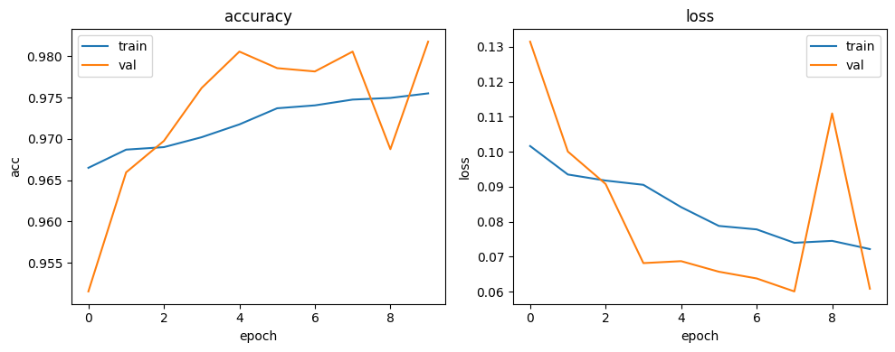

```python
# plotting the train and validation curves
import matplotlib.pyplot as plt
plt.figure(figsize=(10,4))
plt.subplot(1,2,1); plt.plot(hist2.history['accuracy'], label='train'); plt.plot(hist2.history['val_accuracy'], label='val'); plt.title('accuracy'); plt.xlabel('epoch'); plt.ylabel('acc'); plt.legend()
plt.subplot(1,2,2); plt.plot(hist2.history['loss'], label='train'); plt.plot(hist2.history['val_loss'], label='val'); plt.title('loss'); plt.xlabel('epoch'); plt.ylabel('loss'); plt.legend()
plt.tight_layout(); plt.show()
```